# Project Four - Stochastic Programming

Group 10: Matthew Leong, Luke Bravo, Mervyn Jonathan, Joe Niehaus

4/22/2021

### Project Overview

In this project, we will extend the Newsvendor (NV) model in a few ways to better approximate reality. In our first extension, we will assume that if you don’t print enough newspapers to satisfy demand, then you can send a rush order to the printers to print all that you need; additionally, if you print more than the demand you must pay a disposal fee of t dollars per newspaper. For simplicity’s sake, we do not account for options like recycling where they may be some positive value of t.

#### `1` Fitting Linear Regression to Model Demand

We start off simple, using R to fit a linear model regressing demand on price, which yields the following equation:

Demand = 1924.7175 + (Price)(-1367.71)

See relevant code below.

```r
# Fit a linear regression using R
lin_model = lm(demand ~ price, data)
summary(lin_model)
```

```
##
## Call:
## lm(formula = demand ~ price, data = data)
##
## Residuals:
##     Min      1Q  Median      3Q     Max
## -346.91 -104.55   12.89  100.22  341.42
##
## Coefficients:
##             Estimate Std. Error t value Pr(>|t|)
## (Intercept)   1924.7      111.3   17.29   <2e-16 ***
## price        -1367.7      108.4  -12.62   <2e-16 ***
## ---
## Signif. codes:  0 '***' 0.001 '**' 0.01 '*' 0.05 '.' 0.1 ' ' 1
##
## Residual standard error: 151 on 97 degrees of freedom
## Multiple R-squared:  0.6215, Adjusted R-squared:  0.6176
## F-statistic: 159.3 on 1 and 97 DF,  p-value: < 2.2e-16
```

#### `2` Generating Demand Data

We get demand at any given point by adding the residuals from the regression above to the data to get demand when the price is one dollar.

```r
c = 0.5 # Printing cost
g = 0.75 # Rush-print cost
t = 0.15 # Disposal fee
p = 1 # Price

# Get demand residual points of the linear regression and store it
data_resid = data %>% mutate(residuals = residuals(lin_model))

# Add the residuals to the data to get demand at price 1
# Intuitively residuals are unexplained errors, add them to the model to get 100% explanation from the model.
# If you want to check this, I suggest changing p to a price in the demand data. You will get the demand at that price.
demand_p1 = data_resid %>% mutate(pred_demandp1 = lin_model$coefficients[1] + lin_model$coefficients[2]*p + data_resid[,"residuals"])
```

#### `3` Finding Optimal Quantity to Produce when Price = $1.00

This problem is similar to the Newsvendor one we did in class but with some key differences. Namely, we have two conditions. We detail the first as when we produce too much and the second as when we produce too little both relative to the optimal demand. A note about this condition is that since rush printing costs are still less than the revenue we get from printing them, we always choose to rush print.

*As a reminder for the following c is printing cost, g is rushed printing cost, t is disposal fee, and p is price.*

$$pD_i-qc-t(q-D_i) \, if \, q > D_i \\
pD_i-qc-g(D_i-q) \, if \, q \leq D_i$$

$$h_i \leq pD_i-qc-t(q-D_i) \\
h_i + qc +t(q-D_i) \leq pD_i \\
h_i + q(c+t) \leq (p+t)D_i \\$$

*If you’re confused about why t is positive for demand. Think of it as canceling out the disposal fee in the quantity side. tD cancels part of tq essentially. There is still a disposal fee but now it correctly only takes into account the quantity that is actually disposed (q-D)t.*

$$h_i \leq pD_i - qc - g(D_i-q) \\
h_i +qc-qg \leq pD_i - gD_i \\
h_i +q(c-g) \leq (p-g)D_i$$

*Again for the cost of rushed newspapers. the above seems weird but think of it like this: p-g is the penalty assigned to newspapers. c-g offsets this penalty for all q prepared before hand. The remaining (D-q) then eat up the g penalty. So mathematically, q newspapers cost c and D-q newspapers cost g.*

##### *LP Model*

These two formulations go in the constraint and RHS. See the code for this LP model below.

```r
# Get demand for price 1
demand = demand_p1[,"pred_demandp1"]
# Number of days of demand data, if you check data, there are 99 rows which this matches
nd = length(demand)

# Decision variables are (q, h1, h2, ..., h99)
# Objective is the same as in class. Take the average of all the days. Letting h be profit for each day.
obj = c(0,rep(1/nd,nd))
lb = c(0,rep(-Inf,nd)) # Quantity printed needs to be non-negative, but profit on a given day could possibly be negative

# Number of constraints is number of days*2 ()
A = matrix(0,2*nd,nd+1)
rhs = rep(0,2*nd)
dir = rep('<=',2*nd)


for(r in 1:nd){ # For every day create two constraints
  # This is the constraint where q > D
  # h_i + q(c+t) \ leq (p+t)D_i
  A[2*r-1,c(1,r+1)] = c(c+t,1) # q first, 1 for h_i
  rhs[2*r-1] = (p+t)*demand[r] # Represents the demand part

  # This is the constraint where q < D
  # h_i +q(c-g) \ leq (p-g)D_i
  A[2*r,c(1,r+1)] = c(c-g,1) # q first, 1 for h_i
  rhs[2*r] = (p-g)*demand[r]
}

nv.model = list()
nv.model$modelsense = 'max'
nv.model$obj = obj
nv.model$A = A
nv.model$rhs = rhs
nv.model$sense = dir
nv.model$lb = lb

pars = list()
pars$outputflag = 0

nv.sol = gurobi(nv.model,params=pars)
```

##### *LP Model Results*

Using the model above tells us that optimal production level is 472 newspapers,and our expected profit is $231.48

#### `4` Using a Quadratic Model to Make Demand a Function of Price as Well

QP is a bit simpler than QCP, because QP involves less matrix multiplication overall. The suggestion is having h be the negative cost on each day. The quadratic part would be the average revenue.

*General form:*

$$max \, x^{T} Q x + c^{T}x$$

*How does letting price impact demand change the problem? Recall step 1 and 2.*

$$p*D_i = p(\beta_0+\beta_1*p+\epsilon)$$

*That is:*

```r
lin_model$coefficients[1] + lin_model$coefficients[2]*p + data_resid[,"residuals"]
```

```
##        1        2        3        4        5        6        7        8
## 351.3856 579.5202 472.2196 448.9372 673.7490 453.1346 430.1032 480.8745
##        9       10       11       12       13       14       15       16
## 554.1974 720.8431 449.5830 262.9372 617.8340 653.1974 569.8968 623.9686
##       17       18       19       20       21       22       23       24
## 224.2601 385.0628 544.7085 690.8968 593.5830 634.5202 522.2287 703.5111
##       25       26       27       28       29       30       31       32
## 471.8654 722.4261 216.3229 299.9059 828.3543 693.4261 290.0314 339.2287
##       33       34       35       36       37       38       39       40
## 652.9281 631.4170 848.3229 660.2287 643.2601 678.8117 597.1569 409.5830
##       41       42       43       44       45       46       47       48
## 647.8968 719.8340 547.4170 527.1346 485.4798 588.5425 495.2915 610.5111
##       49       50       51       52       53       54       55       56
## 583.6771 539.4484 700.0628 557.2196 700.2601 647.5425 445.4170 560.7085
##       57       58       59       60       61       62       63       64
## 233.0941 467.4170 723.5739 878.2915 593.7399 438.7085 575.5111 422.6457
##       65       66       67       68       69       70       71       72
## 512.1660 210.0941 701.7804 478.5739 543.9686 614.5425 678.8117 668.0941
##       73       74       75       76       77       78       79       80
## 552.8026 815.7713 610.1569 762.1660 527.0628 667.9372 898.4261 417.8745
##       81       82       83       84       85       86       87       88
## 654.2196 551.0628 529.5111 628.5425 406.2196 675.9281 561.7085 363.0314
##       89       90       91       92       93       94       95       96
## 359.2287 451.7804 324.3856 367.5516 626.4484 600.3856 498.8026 669.1032
##       97       98       99
## 441.7085 858.3543 601.4484
```

*In this problem, we always strive to hit $pD_i$ thus, we can consider average revenue to be then:*

$$\frac{\beta_1p^2+(\beta_0 +\epsilon)p}{numberofdays}*numberofdays$$

*Negative cost on the other hand is the h’s. Let us then consider the cases:*

$$-qc-t(q-D_i) \, if \, q > D_i \\
-qc-g(D_i-q) \, if \, q \leq D_i$$

*Need to convert D to the appropriate equation:*

$$-qc-t(q -(\beta_0+\beta_1*p+\epsilon)) = -(qc+t(q-\beta_0-\beta_1*p-\epsilon)) \\
-qc-g((\beta_0+\beta_1*p+\epsilon)-q) = -(qc+g(\beta_0+\beta_1*p+\epsilon-q))$$

*So bringing that together we have:*

$$Average Revenue - Cost each day \\
\frac{\beta_1p^2+\beta_0 p+\epsilon p}{n}*n -h_i$$

*An interesting property if you recall is that the sum of residuals is actually 0. (if you don’t believe me you can check: sum(data_resid[,“residuals”])) Average revenue thus is just the two coefficients of the linear regression model multiplied by price. How to formulate? Decision variables are:*

$$x = [p,q,h_{11},h_{12},...]$$

*New let h be the cost.*

*First the more quantity constraints*

$$h_i \leq -(qc+t(q-\beta_0-\beta_1*p-\epsilon)) \\
h_i \leq -qc - -t(q-\beta_0-\beta_1*p-\epsilon) \\
h_i + qc + tq \leq t\beta_0 + t \beta_1*p+t\epsilon \\
h_i + (t+c)q - t\beta_1*p \leq t(\beta_0+\epsilon)$$

*Less quantity constraints:*

$$h_i \leq -(qc+g(\beta_0+\beta_1*p+\epsilon-q)) \\
h_i +qc \leq -g(\beta_0+\beta_1*p+\epsilon-q) \\
h_i +qc-qg + g\beta_1*P \leq -g(\beta_0+\epsilon)$$

*Interesting thing to note is that only $p^2$ is quadratic meaning that the hint is very applicable. We only need p in the x vector to be quadratic. The rest is linear. That means the gurobi objective function should look something like this:*

$$Q =
\begin{pmatrix}
\beta_1 & 0 & 0 & ..... & 0\\
0 & ... & ... & ... & 0 \\
. & . & . & . & . \\
. & . & . & . & . \\
. & ... & ... & ... & 0
\end{pmatrix}$$

*Basically first term is just the coefficient of linear regression divided by number of days. This captures the quadratic part of the model. Meanwhile the linear should be:*

$$\beta_0p + 0*q + hpart$$

`hpart` *is negative costs. Hence the add for h.*

##### *QP Model*

Ok, let’s try everything described above in Gurobi!

```r
# Get demand for price 1

# Number of days of demand data, if you check data, there are 99 rows which this matches
nd = nrow(data)

# Decision variables are (p,q, h1, h2, ..., h99)
# Total of 2+nd variables. Using all the data that is 101 variables.
# Defining p as the first variable makes things easier.

# Defining quadratic term
# In the class notes this is the middle matrix term
# +2 to account for price and quantity.
quad = matrix(0,nd+2,nd+2)
quad[1,1] = lin_model$coefficients[[2]]

# Defining linear term
# Since first term is price. Assign the appropriate coefficients to the objective
obj = c(lin_model$coefficients[[1]],0,rep(1/nd,nd))
# ub = c(Inf,Inf,rep(Inf,nd))
lb = c(0,0,rep(-Inf,nd))
# Maximizing over

# number of constraints is number of days*2 ()
A = matrix(0,2*nd,nd+2)
rhs = rep(0,2*nd)
dir = rep('<',2*nd)

# Friendly reminder that p is first, q is second.
for(r in 1:nd){ # For every day create two constraints
  # This is the constraint where q > D
  #h_i + (t+c)q - t\beta_1*p \leq t(\beta_0+\epsilon)
  A[2*r-1,c(1,2,r+2)] = c(-t*lin_model$coefficients[2],(c+t),1)
  rhs[2*r-1] = t*(lin_model$coefficients[1]+data_resid$residuals[[r]])

  # This is the constraint where q < D
  #h_i + q(g-c) - gp\beta_1 \leq g(\beta_0 + \epsilon)
  A[2*r,c(1,2,r+2)] = c(g*(lin_model$coefficients[2]), (c-g) ,1)
  rhs[2*r] = -g*(lin_model$coefficients[1]+data_resid$residuals[[r]])
}

nvqp.model = list()
nvqp.model$modelsense = 'max'

# This takes in the quadratic part of the objective function
nvqp.model$Q = quad

# This takes the linear part of the objective function
nvqp.model$obj = obj

# Should be fine since linear constraints.
nvqp.model$A = A
nvqp.model$rhs = rhs
nvqp.model$sense = dir
#nvqp.model$ub = ub
nvqp.model$lb = lb


params = list()
params$outputflag = 0
qp.nvqp = gurobi(nvqp.model,params=params)
#qp.nvqp$x
```

##### *QP Results*

Using the model above tells us that optimal price is $0.95, optimal quantity is 535 newspapers, and expected profit is $234.42.

#### `6` Sensitivity Analysis Using Bootstrap Sampling

Next, we want to know how sensitive the optimal price and quantity are to our data set; to do this, we take a bootstrap sample of the data, fit new betas to our sample, and find optimal price and quantity from said betas. We repeat this 1000 times and include the results below for your viewing pleasure.

##### *Bootstrap Code*

```r
price_list = c()
quantity_list = c()
profit_list = c()

for (i in 1:1000) {
    bsData = data[sample(nrow(data), round(nrow(data)*0.9), replace=TRUE),]
    nd = nrow(bsData)

bsLin_model = lm(demand ~ price, data = bsData)

    b0 = coef(bsLin_model)[1]
    b1 = coef(bsLin_model)[2]
    obj = c(b0+mean(residuals(lin_model)),0,rep(1/nd,nd))
    lb = c(0,0,rep(-Inf,nd))
    Q = matrix(0,nd+2,nd+2)
    Q[1,1] = b1

    A = matrix(0,2*nd,nd+2)
    rhs = rep(0,2*nd)
    dir = rep('<',2*nd)

    for(r in 1:nd){

      A[2*r-1,c(1,2,r+2)] = c(g*b1,c-g,1) ## Still using all the same cgt from part 2
      rhs[2*r-1] = -g*b0 - g*residuals(lin_model)[r]

      A[2*r,c(1,2,r+2)] = c(-t*b1,c+t,1)
      rhs[2*r] = t*b0 + t*residuals(lin_model)[r]
    }

    q6.model = list()
    q6.model$modelsense = 'max'
    q6.model$Q = Q
    q6.model$obj = obj
    q6.model$A = A
    q6.model$rhs = rhs
    q6.model$sense = dir
    q6.model$lb = lb

    params = list()
    params$outputflag = 0
    bootModel = gurobi(q6.model,params=params)

    price_list = c(price_list, bootModel$x[1])
    quantity_list = c(quantity_list, bootModel$x[2])
    profit_list = c(profit_list, bootModel$objval)
}
```

##### *Bootstrap Results*

Over 1000 sampling iterations, we get the following results:

| Bootstrap Iteration | Optimal Price | Optimal Quantity | Profit |
| --- | --- | --- | --- |
| 1 | 0.9493316 | 546.8256 | 235.8532 |
| 2 | 0.9566220 | 561.7663 | 247.2801 |
| 3 | 0.9617124 | 503.2184 | 223.5391 |
| 4 | 0.9679001 | 523.6854 | 236.7539 |
| 5 | 0.9532384 | 528.5967 | 230.0587 |
| 6 | 0.9685245 | 548.3686 | 248.6986 |
| 7 | 0.9650473 | 518.7889 | 232.7410 |
| 8 | 0.9525859 | 553.7255 | 241.0314 |
| 9 | 0.9477448 | 526.8205 | 225.8937 |
| 10 | 0.9553036 | 530.9522 | 232.3979 |
| 11 | 0.9428897 | 549.5898 | 233.0087 |
| 12 | 0.9675511 | 524.5141 | 236.9290 |
| 13 | 0.9742635 | 487.1626 | 223.3044 |
| 14 | 0.9380026 | 533.2557 | 222.7540 |
| 15 | 0.9549055 | 543.2426 | 237.7438 |
| 16 | 0.9535270 | 518.3640 | 225.5949 |
| 17 | 0.9573974 | 547.3168 | 241.1722 |
| 18 | 0.9451295 | 535.3861 | 228.1070 |
| 19 | 0.9325411 | 577.1288 | 238.3555 |
| 20 | 0.9435586 | 546.5801 | 232.0980 |
| 21 | 0.9509884 | 553.4832 | 239.9021 |
| 22 | 0.9591618 | 517.9001 | 228.7805 |
| 23 | 0.9497702 | 550.8908 | 237.9586 |
| 24 | 0.9498435 | 521.7681 | 224.9045 |
| 25 | 0.9295198 | 573.4341 | 234.7687 |
| 26 | 0.9561294 | 524.1851 | 229.8197 |
| 27 | 0.9425664 | 526.8321 | 222.7317 |
| 28 | 0.9354128 | 558.5871 | 232.1830 |
| 29 | 0.9648855 | 495.8095 | 221.9605 |
| 30 | 0.9403138 | 548.7219 | 230.9923 |

[output cut: 970 more lines]

#### `7` Visualization for our 1000 Sampling Iterations

Below, the scatterplot visualizes the spread of optimal price and quantity results for each of our 1000 samples; the marginal histograms further illustrate the frequency distributions of price and quantity.

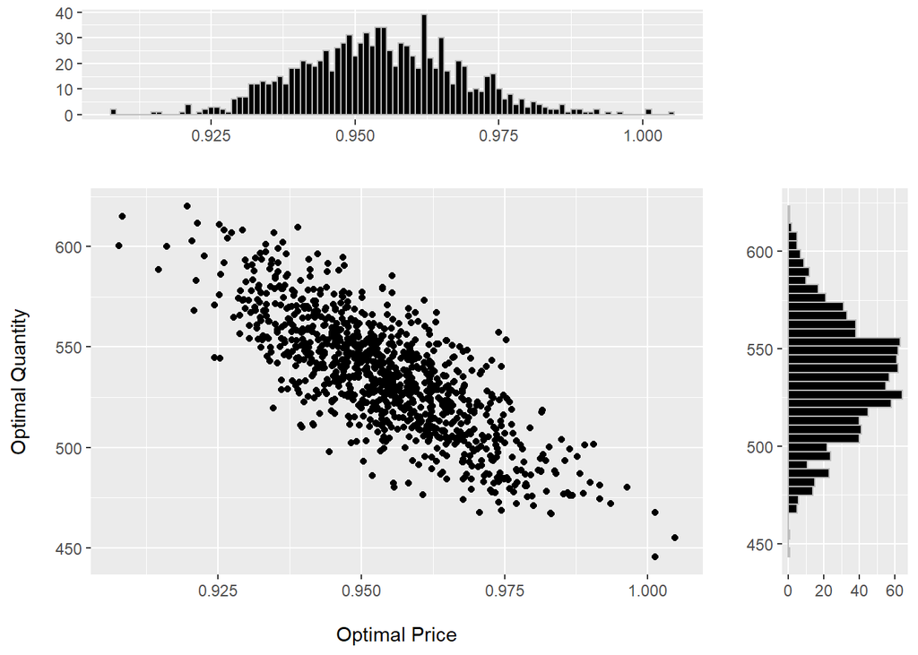

#### `8` Comparing Our Boss’ Standard Newsvendor Approach to our QP Approach

Our quadratic programming approach is more accurate and more responsive to changing demand than the basic newsvendor approach. Our QP approach extends the NV model to account for disposal and rush printing costs which result from dynamic demand. As such, this approach is more accurate. The QP approach yields higher revenue (see the distribution of profit generated by our 1000 bootstrap samples below) based on optimal expected values and the median of the profits below.

Median Expected Profts: $233.38

Mode of Expected Profts: $235.85

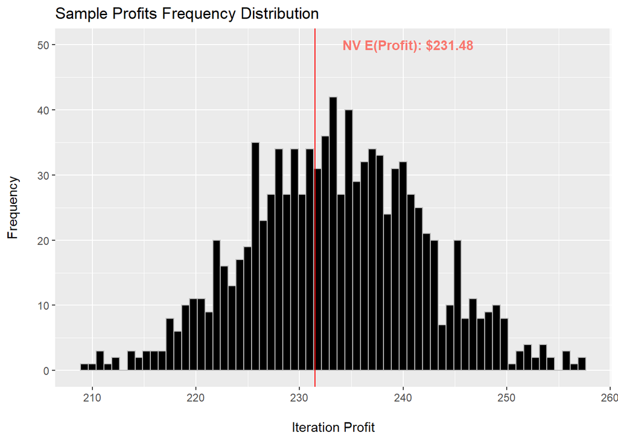